# 2015-03-02-Dane Holding-HW2

Dane Holding

Sunday, March 01, 2015

The initial cleaning code ripped from Elliot’s repository.

```r
if (!require(ggplot2)) install.packages("ggplot2")
library(ggplot2)
if (!require(RColorBrewer)) install.packages("RColorBrewer")
library(RColorBrewer)

setwd("C:/Users/Dane/Desktop/QMSS/hw2")
germs <- read.csv(file="Microbe-scope-bugs.csv", header=TRUE)

## pre-processing
# assign descriptive column names where absent
names(germs)[1]<-"germ"

# how could you do this more carefully???
# names(germs)[10]<-"yearly.fatalities.rounded"
# names(germs)[11]<-"yearly.fatalities.raw"

# keep only data columns, exclude notes/links
notes <- germs[1, ] # save the notes?
germs <- germs[-1, ] # remove **row** of notes
# germs <- germs[, c(2, 4:7, 9:11)] # keep data **columns** only
# how could you do this more carefully??? e.g. remove the columns you intend to remove.

# how about something like this?
notes <- grep(pattern="note", x=names(germs), ignore.case=TRUE)
names(germs)[notes] # double check we got the right columns
```

```
## [1] "note"   "note.1" "note.2"
```

```r
germs <- subset(germs, select = -notes) # apply filter.

# any more columns we want to omit?

# remove percent signs
dropPct<-function(df, var){
  dropPct<-strsplit(as.character(df[[var]]), split="%")
  df[[var]]<-as.numeric(dropPct)
  return(df[[var]])
}
```

I then further cleaned up the data by eliminating Anthrax, replacing cholera’s mode of transmission as “fecal-oral”, and then transforms basic reproductive rate, which has turned into a factor for some reason.

```r
# remove % signs, leaving a numeric value.
germs[["case.fatality.rate"]]<-dropPct(germs, "case.fatality.rate")

germs <- germs[-1, ] #drops Anthrax since I can't find its R0
germs$primary.mode.of.transmission[germs$primary.mode.of.transmission==""] <- "fecal-oral"
germs$average.basic.reproductive.rate <- as.numeric(as.character(germs$average.basic.reproductive.rate))
```

Creates an initial Scatter plot

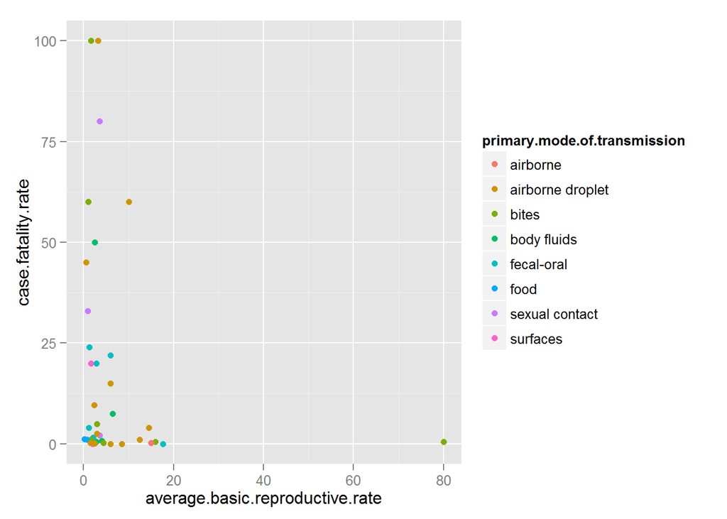

```r
qplot(average.basic.reproductive.rate, case.fatality.rate, data=germs, colour=primary.mode.of.transmission, geom = c("point"))
```

This is some artifacty-type stuff from when I was playing around with different kinds of libraries. I was trying to develop an aesthetic for my plot, but it didn’t work out. Brewer allows you to create a number of gradients within a certain color, so that you can use them within your plots. I eventually use some of these objects to code the color of my axis titles.

```r
palette <- brewer.pal("Greys", n=9)
color.background = palette[2]
color.grid.major = palette[3]
color.axis.text = palette[6]
color.axis.title = palette[7]
color.title = palette[9]
```

Finally, the money shot. I had a couple of issues in creating this graph: foremost among them was my inability to position the labels in such a way where they didn’t overlap. I also had some trouble setting break points and numerical labels on the logged Y axis.

To see the plot in full resolution, right click and select “view image.” Sorry, I like really hi-res images. However, on that note. There’s also a few, lingering overlapping labels.

To further clean this up, I would clean the data bit more effectively, fix the legend, try to jitter the labels so that they don’t overlap, and add the annotations.

```
## Warning: Removed 1 rows containing missing values (geom_point).
```

```
## Warning: Removed 1 rows containing missing values (geom_text).
```

[figure not shown]

```r
graph <- ggplot(germs, aes(x=average.basic.reproductive.rate,
                  y=case.fatality.rate, colour=primary.mode.of.transmission)) +
  theme_bw(base_size=50) +
  geom_point(size=6, alpha=.3) +
  geom_text(aes(label=germ, hjust = 0.15, vjust=-.7, angle = 20, size=2)) +
  ggtitle("The Microbe-scope") +
  xlab("Contagiousness (Average Basic Reproduction Number/Number of People One Person will Likely Infect)") +
  scale_color_discrete(name="Primary Mode of Transmission") +
  scale_x_continuous(breaks=seq(0,18, by=1),
                     limits = c(0,18)) +
  scale_y_log10("Deadliness(Case Fatatlity Rate)", limits = c(0.001,150), breaks =c(0.001, 0.1, 1,10, 20,30,40,50,60,70,80,90,100), labels = c(0.001, 0.1, 1,10, 20,30,40,50,60,70,80,90,100)) +
  theme(plot.title = element_text(size=36, colour=color.axis.text)) +
  theme(axis.text.x = element_text(size=9.5, colour=color.axis.text)) +
  theme(axis.text.y = element_text(size=9.5, colour=color.axis.text)) +
  theme(axis.title.x = element_text(size=20, colour=color.axis.text)) +
  theme(axis.title.y = element_text(size=20, colour=color.axis.text)) +
  theme(legend.title = element_text(size=14, colour=color.axis.text)) +
  theme(legend.text = element_text(size=12, colour=color.axis.text))
```